# The optimal we found is not the best we want

# An additive Gaussian process regression model

Given a set of input variables $\mathbf{t} = \left\lbrace t_1,\ldots,t_n\right\rbrace$ for function $f(t)$ and the output $\mathbf{y}=f(\mathbf{t})+\varepsilon$ with i.i.d Gaussian noise $\varepsilon$ of variance $\sigma_n^2$, we can use the above definition to predict the value of the function $f_*=f(t_*)$ at a particular input $t_*$. As the noisy observations becoming
$$\begin{equation}
\mathrm{Cov} (y_p,y_q) = K(t_p,t_q)+\sigma_n^2 \delta_{pq}
\end{equation}$$
where $\delta_{pq}$ is a Kronecker delta which is one if and only if $p=q$ and zero otherwise, the joint distribution of the observed outputs $\mathbf{y}$ and the estimated output $f_*$ according to prior is
$$\begin{equation}
\begin{bmatrix}
\mathbf{y}\\ f_*\end{bmatrix} \sim N \left( 0, \begin{bmatrix}
K(\mathbf{t},\mathbf{t}) +\sigma_n^2I& K(\mathbf{t},t_*) \\
K(t_*,\mathbf{t}) & K(t_*,t_*)
\end{bmatrix}
\right).
\end{equation}$$
The posterior distribution over the predicted value is obtained by conditioning on the observed data
$$\begin{equation}
f_* \mid \mathbf{y},\mathbf{t},t_* \sim N\left(\bar{f_*},\mathrm{Cov} (f_*)\right)
\end{equation}$$
where
$$\begin{align}
\bar{f_*}&=\mathrm{E} \left( f_* \mid \mathbf{y},\mathbf{t},t_*\right) = K(t_*,\mathbf{t})\left( K(\mathbf{t},\mathbf{t})+\sigma_n^2\right) ^{-1}\mathbf{y},\\
\mathrm{Cov}(f_*)&=K(t_*,t_*)-K(t_*,\mathbf{t})\left( K(\mathbf{t},\mathbf{t})+\sigma_n^2I\right) ^{-1}K(\mathbf{t},t_*).
\end{align}$$
Therefore it can seen that the Bayesian estimation of a smoothing spline is a special format of Gaussian process regression with diffuse prior and the covariance matrix $R(s,t)$.

Cheng et al. (2019) proposed an additive Gaussian process regression model for fitting longitudinal data in biomedical (biostatistical) research.

For example,

$$\begin{align*}
\mbox{AGPM1: } y&=f^{(1)}(id)+\varepsilon \\
\mbox{AGPM2: } y&=f^{(1)}(id)+f^{(2)}(age)+f^{(3)}(id\times age)+\varepsilon \\
\mbox{AGPM3: } y&=f^{(1)}(id)+f^{(2)}(age)+f^{(3)}(id\times age)+f^{(4)}(loc)+f^{(5)}(loc\times age)+\varepsilon
\end{align*}$$

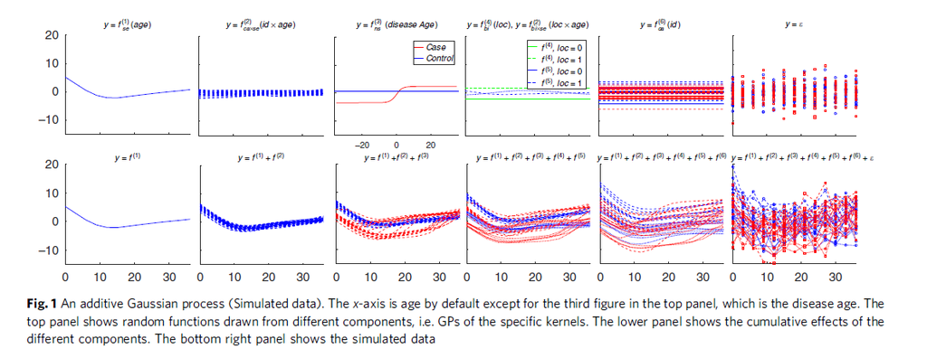

```r
knitr::include_graphics("agpm.png",dpi=100)
```

However, `LonGP`, a software to implement additive Gaussian process regression, is only available in `Matlab` and `Linux` (or `Mac`) system.

Here we propose another research topic: **Additive Gaussian process regression model on longitudinal agricultural data**, and plan to develop an `R` package, which will be widely used for statisticians on their PCs.

# References

Chen, Kefei, Rebecca A. O’Leary, and Fiona H. Evans. 2019. “A Simple and Parsimonious Generalised Additive Model for Predicting Wheat Yield in a Decision Support Tool.” *Agricultural Systems* 173: 140–50.

Cheng, Lu, Siddharth Ramchandran, Tommi Vatanen, Niina Lietzén, Riitta Lahesmaa, Aki Vehtari, and Harri Lähdesmäki. 2019. “An Additive Gaussian Process Regression Model for Interpretable Non-Parametric Analysis of Longitudinal Data.” *Nature Communications* 10 (1): 1798.

Meyer, Mary C. 2008. “Inference Using Shape-Restricted Regression Splines.” *The Annals of Applied Statistics* 2 (3): 1013–33.

———. 2013. “Semi-Parametric Additive Constrained Regression.” *Journal of Nonparametric Statistics* 25 (3): 715–30.

Pya, Natalya. 2010. “Additive Models with Shape Constraints.” PhD thesis, University of Bath.

Pya, Natalya, and Simon N. Wood. 2015. “Shape Constrained Additive Models.” *Statistics and Computing* 25 (3): 543–59.

Wood, Simon, and Maintainer Simon Wood. 2015. “Package ‘Mgcv’.” *R Package Version* 1: 29.

Wood, S. N. 2006. “Generalized Additive Models: An Introduction with R.”

Xiyue Liao, Mary C. Meyer. 2019. “Cgam: An R Package for the Constrained Generalized Additive Model.” *Journal of Statistical Software* 89 (5). [https://doi.org/doi: 10.18637/jss.v089.i05](https://doi.org/doi:%2010.18637/jss.v089.i05).